# HW1 - KC Housing

KC Housing Project for aap

## Data Information

Kaggle source:

https://www.kaggle.com/harlfoxem/housesalesprediction

Basic data dictionary:

https://geodacenter.github.io/data-and-lab//KingCounty-HouseSales2015/

Link to discussion item meaning of CONDITION and GRADE fields:

https://www.kaggle.com/harlfoxem/housesalesprediction/discussion/141767

## Preliminaries

```python
# To auto-reload modules in jupyter notebook (so that changes in files *.py doesn't require manual reloading):
# https://stackoverflow.com/questions/5364050/reloading-submodules-in-ipython
%load_ext autoreload
%autoreload 2
```

```
The autoreload extension is already loaded. To reload it, use:
  %reload_ext autoreload
```

Import commonly used libraries and magic command for inline plotting

```python
import numpy as np
import pandas as pd
import matplotlib.pyplot as plt
import seaborn as sns
```

```python
%matplotlib inline
```

## Load data from csv

The data for this classification problem can be found in ./data/raw/kc_house_data_classification.csv.

```python
housing_df = pd.read_csv("./data/kc_house_data_classification.csv")
```

## Initial EDA

```python
housing_df.info()
```

```
<class 'pandas.core.frame.DataFrame'>
RangeIndex: 21613 entries, 0 to 21612
Data columns (total 19 columns):
 #   Column         Non-Null Count  Dtype
---  ------         --------------  -----
 0   bedrooms       21613 non-null  int64
 1   bathrooms      21613 non-null  float64
 2   sqft_living    21613 non-null  int64
 3   sqft_lot       21613 non-null  int64
 4   floors         21613 non-null  float64
 5   waterfront     21613 non-null  int64
 6   view           21613 non-null  int64
 7   condition      21613 non-null  int64
 8   grade          21613 non-null  int64
 9   sqft_above     21613 non-null  int64
 10  sqft_basement  21613 non-null  int64
 11  yr_built       21613 non-null  int64
 12  yr_renovated   21613 non-null  int64
 13  zipcode        21613 non-null  int64
 14  lat            21613 non-null  float64
 15  long           21613 non-null  float64
 16  sqft_living15  21613 non-null  int64
 17  sqft_lot15     21613 non-null  int64
 18  price_gt_1M    21613 non-null  int64
dtypes: float64(4), int64(15)
memory usage: 3.1 MB
```

```python
housing_df.iloc[:5, :10]
```

|  | bedrooms | bathrooms | sqft_living | sqft_lot | floors | waterfront | view | condition | grade | sqft_above |
| --- | --- | --- | --- | --- | --- | --- | --- | --- | --- | --- |
| 0 | 3 | 1.00 | 1180 | 5650 | 1.0 | 0 | 0 | 3 | 7 | 1180 |
| 1 | 3 | 2.25 | 2570 | 7242 | 2.0 | 0 | 0 | 3 | 7 | 2170 |
| 2 | 2 | 1.00 | 770 | 10000 | 1.0 | 0 | 0 | 3 | 6 | 770 |
| 3 | 4 | 3.00 | 1960 | 5000 | 1.0 | 0 | 0 | 5 | 7 | 1050 |
| 4 | 3 | 2.00 | 1680 | 8080 | 1.0 | 0 | 0 | 3 | 8 | 1680 |

Take a look at the first five rows of the first 10 variables.

```python
housing_df.iloc[:5, 10:]
```

|  | sqft_basement | yr_built | yr_renovated | zipcode | lat | long | sqft_living15 | sqft_lot15 | price_gt_1M |
| --- | --- | --- | --- | --- | --- | --- | --- | --- | --- |
| 0 | 0 | 1955 | 0 | 98178 | 47.5112 | -122.257 | 1340 | 5650 | 0 |
| 1 | 400 | 1951 | 1991 | 98125 | 47.7210 | -122.319 | 1690 | 7639 | 0 |
| 2 | 0 | 1933 | 0 | 98028 | 47.7379 | -122.233 | 2720 | 8062 | 0 |
| 3 | 910 | 1965 | 0 | 98136 | 47.5208 | -122.393 | 1360 | 5000 | 0 |
| 4 | 0 | 1987 | 0 | 98074 | 47.6168 | -122.045 | 1800 | 7503 | 0 |

Take a look at the first five rows of the other variables.

```python
cols_to_keep = housing_df.columns.tolist()
cols_to_keep
```

```
['bedrooms',
 'bathrooms',
 'sqft_living',
 'sqft_lot',
 'floors',
 'waterfront',
 'view',
 'condition',
 'grade',
 'sqft_above',
 'sqft_basement',
 'yr_built',
 'yr_renovated',
 'zipcode',
 'lat',
 'long',
 'sqft_living15',
 'sqft_lot15',
 'price_gt_1M']
```

Create a list of all the column names for later use.

## Automated EDA

### ydata-profiling

```python
from ydata_profiling import ProfileReport
```

```python
profile = ProfileReport(housing_df, title="Pandas Profiling Report")
```

```python
profile.to_file("output/pandas_profiling_report.html")
```

### Sweetviz

```python
import sweetviz
```

```python
report = sweetviz.analyze(housing_df)
```

```
                                             |                | [  0%]   00:00 -> (? left)
```

```python
report.show_html("output/sweetviz_report.html")
```

```
Report output/sweetviz_report.html was generated! NOTEBOOK/COLAB USERS: the web browser MAY not pop up, regardless, the report IS saved in your notebook/colab files.
```

Through the two HTML files from these two Automated EDAs, I observed that:

- The binary target variable, `price_gt_1M`, is highly imbalanced. Over 90% of the houses in the dataset are priced less than a million dollars (belonging to the 0 class).
- The target variable, `price_gt_1M`, shows positive pairwise correlations with all other variables in the dataset, although to varying degrees.

### Target variable - price_gt_1M

```python
housing_df.groupby(['price_gt_1M']).size()
```

```
price_gt_1M
0    20121
1     1492
dtype: int64
```

```python
housing_df['price_gt_1M'].value_counts(normalize=True)
```

```
price_gt_1M
0    0.930967
1    0.069033
Name: proportion, dtype: float64
```

### Categorize feature types

To create a list of numeric variables and a list of categorical variables.

```python
housing_df.nunique()
```

```
bedrooms           13
bathrooms          30
sqft_living      1038
sqft_lot         9782
floors              6
waterfront          2
view                5
condition           5
grade              12
sqft_above        946
sqft_basement     306
yr_built          116
yr_renovated       70
zipcode            70
lat              5034
long              752
sqft_living15     777
sqft_lot15       8689
price_gt_1M         2
dtype: int64
```

By examining the number of unique values in each variable, I found that all variables with fewer than or equal to 5 unique values are all categorical variables. However, there are exceptions. For example, `zipcode` and `grade`, which contains way more than 5 unique values, but should be classified as categorical conceptually.

```python
categorical_cols = [col for col in housing_df.columns[:-1] if housing_df[col].nunique() < 6] + ['zipcode'] + ['grade']
```

```python
numeric_cols = [col for col in housing_df.columns[:-1] if col not in categorical_cols]
```

Then, I put the rest of the variables into the numeric list.

```python
print(type(categorical_cols))
print(type(numeric_cols))
```

```
<class 'list'>
<class 'list'>
```

```python
assert len(cols_to_keep[:-1]) == len(categorical_cols) + len(numeric_cols)
```

Examine the results. Nothing happens, so each column (predictor) is either in categorical or numeric lists.

```python
categorical_cols_idx = [housing_df.columns.get_loc(c) for c in categorical_cols]
categorical_cols_idx
```

```
[5, 6, 7, 13, 8]
```

```python
numeric_cols_idx = [housing_df.columns.get_loc(c) for c in numeric_cols]
numeric_cols_idx
```

```
[0, 1, 2, 3, 4, 9, 10, 11, 12, 14, 15, 16, 17]
```

Here, I also got the column index numbers for categorical variables.

```python
housing_df.iloc[:, categorical_cols_idx].nunique()
```

```
waterfront     2
view           5
condition      5
zipcode       70
grade         12
dtype: int64
```

### Data Transforms

```python
from sklearn.compose import ColumnTransformer
from sklearn.pipeline import Pipeline, make_pipeline
from sklearn.preprocessing import StandardScaler, OneHotEncoder
from sklearn.linear_model import LogisticRegression, LogisticRegressionCV
from sklearn.model_selection import train_test_split
```

### Data Partitioning

```python
X = housing_df.iloc[:, 0:18]
y = housing_df.iloc[:, 18]
X_train, X_test, y_train, y_test = train_test_split(X, y, test_size=0.2, random_state=73)
```

## Task 4 - Logistic Regression models

### Model 0: The null model

```python
from sklearn.dummy import DummyClassifier
```

```python
# Create transformer objects
numeric_transformer = StandardScaler()
categorical_transformer = OneHotEncoder(handle_unknown='ignore')

# Combine transformers into a preprocessor step
preprocessor = ColumnTransformer(
    transformers=[
        ('num', numeric_transformer, numeric_cols),
        ('cat', categorical_transformer, categorical_cols)])

# Null model
clf_model0 = DummyClassifier(strategy="most_frequent")

# Append to preprocessing pipeline
clf = Pipeline(steps=[('preprocessor', preprocessor),
                      ('classifier', clf_model0)])

# Fit model on new training data
clf.fit(X_train, y_train)

print(f"Training score: {clf.score(X_train, y_train):.3f}")
print(f"Test score: {clf.score(X_test, y_test):.3f}")
```

```
Training score: 0.933
Test score: 0.924
```

The results show that the outcome variable (`price_gt_1M`) is highly imbalanced. Even by simply predicting 0 for every observation, the accuracy score reaches 0.933 on the training dataset and 0.924 on the testing dataset.

### Model 1: Ridge regression with C=1.0

```python
# Ridge regression model
# As "'penalty' was deprecated in version 1.8 and will be removed in 1.10.
# To avoid this warning, leave 'penalty' set to its default value and use 'l1_ratio' or 'C' instead.
# Use l1_ratio=0 instead of penalty='l2', l1_ratio=1 instead of penalty='l1',
# l1_ratio set to a float between 0 and 1 instead of penalty='elasticnet', and C=np.inf instead of penalty=None."
# So I just use l1_ratio=0 here, instead of penalty='l2'.
clf_model1 = LogisticRegression(l1_ratio=0, C=1, solver='saga', max_iter=5000)

# Append classifier to preprocessing pipeline.
clf_1 = Pipeline(steps=[('preprocessor', preprocessor),
                      ('classifier', clf_model1)])

# Fit model on training data
clf_1.fit(X_train, y_train)

print(f"Training score: {clf_1.score(X_train, y_train):.3f}")
print(f"Test score: {clf_1.score(X_test, y_test):.3f}")
```

```
Training score: 0.974
Test score: 0.971
```

```python
from sklearn.metrics import confusion_matrix, ConfusionMatrixDisplay
```

```
Confusion matrix for train, without normalization
[[15984   143]
 [  314   849]]
Normalized confusion matrix for train
[[0.99113288 0.00886712]
 [0.2699914  0.7300086 ]]
```

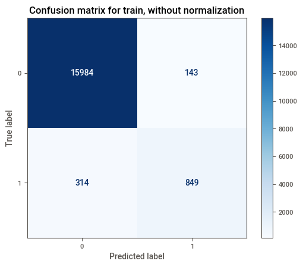

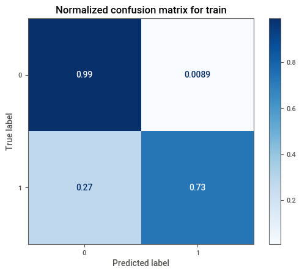

```python
# Create confusion matrices for training data.
titles_options = [("Confusion matrix for train, without normalization", None),
                  ("Normalized confusion matrix for train", 'true')]

class_names = clf_1['classifier'].classes_

for title, normalize in titles_options:
    disp = ConfusionMatrixDisplay.from_estimator(clf_1, X_train, y_train,
                                 display_labels=class_names,
                                 cmap=plt.cm.Blues,
                                 normalize=normalize)
    disp.ax_.set_title(title)

    print(title)
    print(disp.confusion_matrix)

plt.show()
```

```
Confusion matrix for test, without normalization
[[3961   33]
 [  94  235]]
Normalized confusion matrix for test
[[0.99173761 0.00826239]
 [0.28571429 0.71428571]]
```

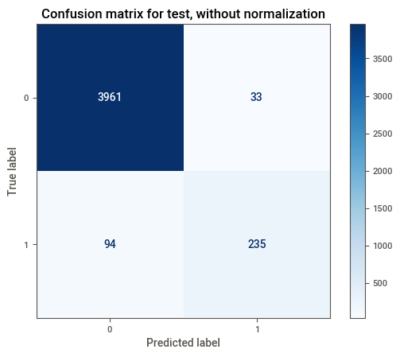

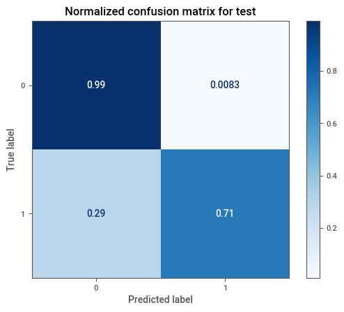

```python
# Create confusion matrices for test data.
titles_options = [("Confusion matrix for test, without normalization", None),
                  ("Normalized confusion matrix for test", 'true')]

class_names = clf_1['classifier'].classes_

for title, normalize in titles_options:
    disp = ConfusionMatrixDisplay.from_estimator(clf_1, X_test, y_test,
                                 display_labels=class_names,
                                 cmap=plt.cm.Blues,
                                 normalize=normalize)
    disp.ax_.set_title(title)

    print(title)
    print(disp.confusion_matrix)

plt.show()
```

```python
# To get the shape of coefficients
clf_1.named_steps['classifier'].coef_.shape
```

```
(1, 107)
```

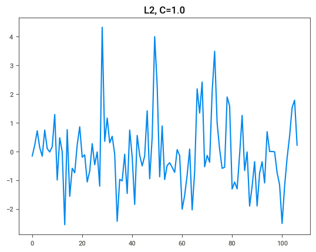

```python
# Create a plot of the coefficients
def coef_plot(model, title=None):
    fig, ax = plt.subplots(1, sharex=True)

    if title:
        ax.set_title(title)

    ax.plot(model.steps[1][1].coef_[0])

coef_plot(clf_1, 'L2, C=1.0')
plt.show()
```

Compared to the null model, the logistic regression model with Ridge regularization (C=1.0) achieved higher accuracy scores on both the training and test sets. The training accuracy is only slightly higher than the test accuracy. Specifically, looking at the confusion matrices for houses valued at equal to or greater than 1 million dollars, the model demonstrated a true positive rate of approximately 0.73 and a false negative rate of approximately 0.27 for the training dataset, and a true positive rate of approximately 0.71 and a false negative rate of approximately 0.29 for the test dataset. The results indicate that the ridge regression model performs better than the null model and does not exhibit clear evidence of overfitting or underfitting.

There are a bunch of non-zero coefficients, indicating that multiple variables either positively or negatively contribute to the model's predictions.

### Model 2: Lasso regression with C=1.0

```python
# Lasso regression model with C=1.0
clf_model2 = LogisticRegression(l1_ratio=1, C=1, solver='saga', max_iter=5000)

# Append classifier to preprocessing pipeline.
clf_2 = Pipeline(steps=[('preprocessor', preprocessor),
                      ('classifier', clf_model2)])

# Fit model on training data
clf_2.fit(X_train, y_train)

print(f"Training score: {clf_2.score(X_train, y_train):.3f}")
print(f"Test score: {clf_2.score(X_test, y_test):.3f}")
```

```
Training score: 0.974
Test score: 0.970
```

```
Confusion matrix for train, without normalization
[[15977   150]
 [  296   867]]
Normalized confusion matrix for train
[[0.99069883 0.00930117]
 [0.25451419 0.74548581]]
```

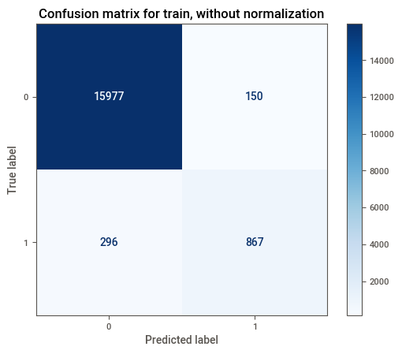

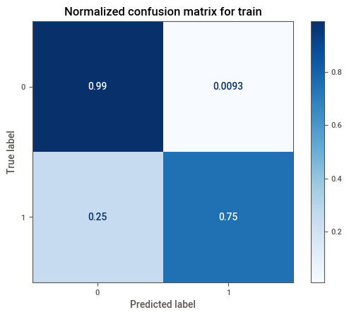

```python
# Create confusion matrices for training data.
titles_options = [("Confusion matrix for train, without normalization", None),
                  ("Normalized confusion matrix for train", 'true')]

class_names = clf_2['classifier'].classes_

for title, normalize in titles_options:
    disp = ConfusionMatrixDisplay.from_estimator(clf_2, X_train, y_train,
                                 display_labels=class_names,
                                 cmap=plt.cm.Blues,
                                 normalize=normalize)
    disp.ax_.set_title(title)

    print(title)
    print(disp.confusion_matrix)

plt.show()
```

```
Confusion matrix for test, without normalization
[[3957   37]
 [  92  237]]
Normalized confusion matrix for test
[[0.9907361  0.0092639 ]
 [0.27963526 0.72036474]]
```

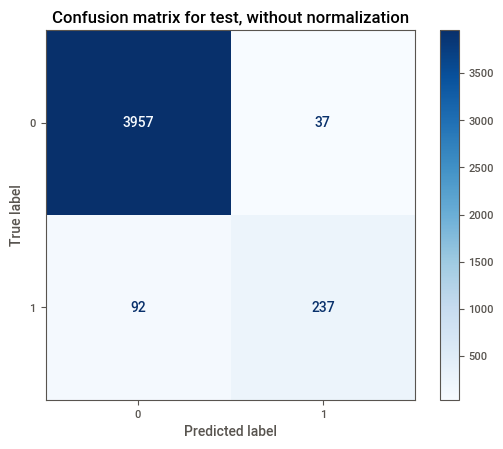

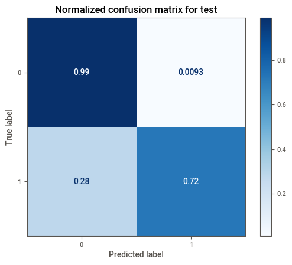

```python
# Create confusion matrices for test data.
titles_options = [("Confusion matrix for test, without normalization", None),
                  ("Normalized confusion matrix for test", 'true')]

class_names = clf_2['classifier'].classes_

for title, normalize in titles_options:
    disp = ConfusionMatrixDisplay.from_estimator(clf_2, X_test, y_test,
                                 display_labels=class_names,
                                 cmap=plt.cm.Blues,
                                 normalize=normalize)
    disp.ax_.set_title(title)

    print(title)
    print(disp.confusion_matrix)

plt.show()
```

```python
# To get the shape of coefficients
clf_2.named_steps['classifier'].coef_.shape
```

```
(1, 107)
```

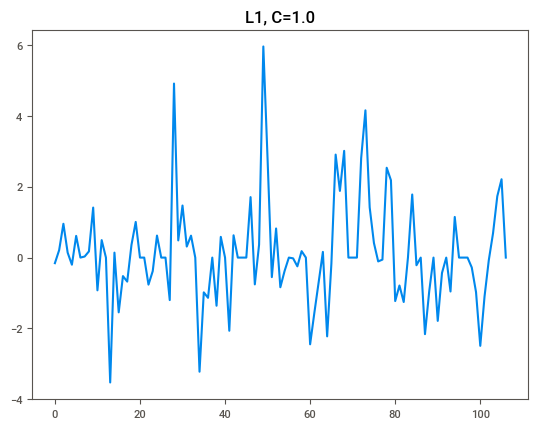

```python
# Create a plot of the coefficients
coef_plot(clf_2, 'L1, C=1.0')
plt.show()
```

Compared to the ridge regression model, the Lasso regression model achieved the same accuracy score on the training set but ended with a slightly lower accuracy score on the test set. Similarly, the Lasso regression model's training accuracy is higher than the test accuracy. Additionally, looking at the confusion matrices for houses valued at equal to or greater than 1 million dollars, the Lasso regression model demonstrated a slightly higher true positive (TP) rate and a slightly lower false negative rate (FN) across both the training and test sets compared to the ridge regression model (TP increases from 0.73 to 0.75 for the training data and increases from 0.71 to 0.72 for the testing data, while FN decreases from 0.27 to 0.25 for the training data and decreases from 0.29 to 0.28 for the testing data). The results indicate that the Lasso regression model performs slightly better than the ridge regression model at correctly identifying houses valued at equal to or greater than 1 million dollars. The results also show no clear evidence of overfitting or underfitting.

Compared to the ridge regression model, although the Lasso regression model still has many non-zero coefficients, more of Lasso's coefficients are set to zero.

### Model 3: Lasso regression with C=0.01

```python
# Lasso regression model with C=0.01
clf_model3 = LogisticRegression(l1_ratio=1, C=0.01, solver='saga', max_iter=5000)

# Append classifier to preprocessing pipeline.
clf_3 = Pipeline(steps=[('preprocessor', preprocessor),
                      ('classifier', clf_model3)])

# Fit model on training data
clf_3.fit(X_train, y_train)

print(f"Training score: {clf_3.score(X_train, y_train):.3f}")
print(f"Test score: {clf_3.score(X_test, y_test):.3f}")
```

```
Training score: 0.954
Test score: 0.950
```

```
Confusion matrix for train, without normalization
[[16005   122]
 [  670   493]]
Normalized confusion matrix for train
[[0.99243505 0.00756495]
 [0.5760963  0.4239037 ]]
```

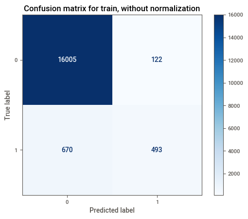

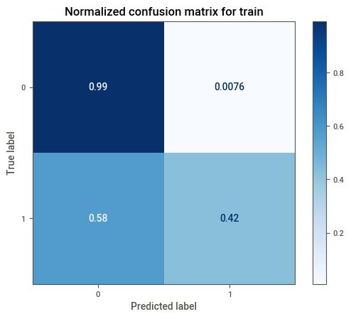

```python
# Create confusion matrices for training data.
titles_options = [("Confusion matrix for train, without normalization", None),
                  ("Normalized confusion matrix for train", 'true')]

class_names = clf_3['classifier'].classes_

for title, normalize in titles_options:
    disp = ConfusionMatrixDisplay.from_estimator(clf_3, X_train, y_train,
                                 display_labels=class_names,
                                 cmap=plt.cm.Blues,
                                 normalize=normalize)
    disp.ax_.set_title(title)

    print(title)
    print(disp.confusion_matrix)

plt.show()
```

```
Confusion matrix for test, without normalization
[[3958   36]
 [ 179  150]]
Normalized confusion matrix for test
[[0.99098648 0.00901352]
 [0.54407295 0.45592705]]
```

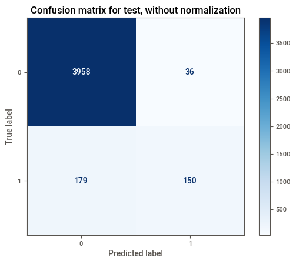

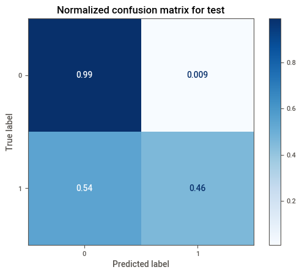

```python
# Create confusion matrices for test data.
titles_options = [("Confusion matrix for test, without normalization", None),
                  ("Normalized confusion matrix for test", 'true')]

class_names = clf_3['classifier'].classes_

for title, normalize in titles_options:
    disp = ConfusionMatrixDisplay.from_estimator(clf_3, X_test, y_test,
                                 display_labels=class_names,
                                 cmap=plt.cm.Blues,
                                 normalize=normalize)
    disp.ax_.set_title(title)

    print(title)
    print(disp.confusion_matrix)

plt.show()
```

```python
# To get the shape of coefficients
clf_3.named_steps['classifier'].coef_.shape
```

```
(1, 107)
```

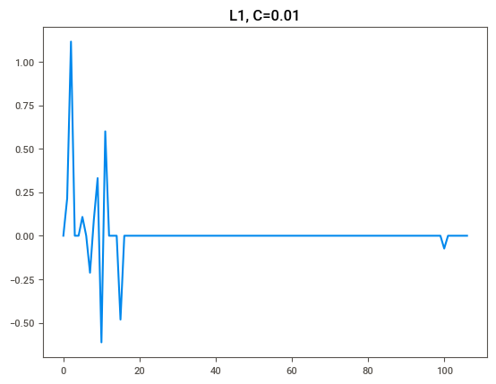

```python
# Create a plot of the coefficients
coef_plot(clf_3, 'L1, C=0.01')
plt.show()
```

Although the Lasso regression model with C=0.01 achieves higher accuracy scores on both the training and test data than the null model, its accuracy is lower than both the ridge regression model with C=1.0 (model 1) and the Lasso regression model with C=1.0 (model 2). The training accuracy score is only 0.004 higher than the test accuracy score, suggesting that the model does not exhibit evidence of overfitting.

Besides, looking at the confusion matrices, for houses valued at 1 million dollars or more, the Lasso regression model with C=0.01 demonstrated a much lower true positive (TP) rate and a much higher false negative rate (FN) across both the training and test sets compared to models 1 and 2. In fact, TP = 0.42 and FN = 0.58 for the training data and TP = 0.46 and FN = 0.54 for the test data. These results indicate that the model correctly predicts only about half of the houses valued at 1 million dollars or more. The results indicate that the stronger regularization reduces the model's ability to correctly classify the minority class in this highly imbalanced classification problem. Overall, this Lasso regression model performs worse than models 1 and 2, and its performance shows evidence of underfitting.

Compared to models 1 and 2, this lasso regression model enforces more regularization and causes many more coefficients to be shrunk to zero. The results are expected because setting a smaller value of C means putting more weight on the regularization penalty term in the logistic regression function. Consequently, the model becomes simpler and loses some predictive power.

### Model 4: Lasso regression with optimal C value

```python
# Lasso regression with optimal C value
clf_model4 = LogisticRegressionCV(l1_ratios=(1,), solver='saga', scoring='accuracy', max_iter=5000, use_legacy_attributes=False)

# Append classifier to preprocessing pipeline.
clf_4 = Pipeline(steps=[('preprocessor', preprocessor),
                      ('classifier', clf_model4)])

# Fit model on training data
clf_4.fit(X_train, y_train)

print(f"Optimal C value: {clf_4.named_steps['classifier'].C_:.3f}")
print(f"Training score: {clf_4.score(X_train, y_train):.3f}")
print(f"Test score: {clf_4.score(X_test, y_test):.3f}")
```

```
Optimal C value: 21.544
Training score: 0.975
Test score: 0.972
```

```
Confusion matrix for train, without normalization
[[15974   153]
 [  287   876]]
Normalized confusion matrix for train
[[0.9905128  0.0094872 ]
 [0.24677558 0.75322442]]
```

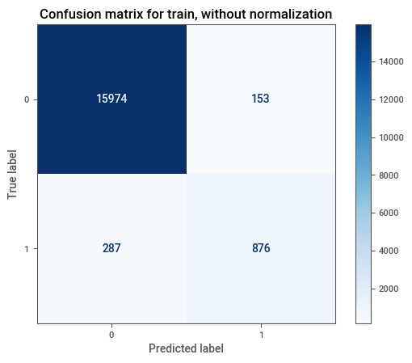

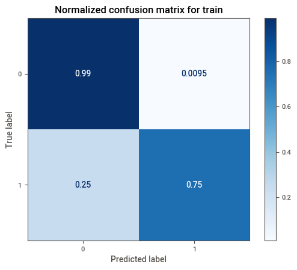

```python
# Create confusion matrices for training data.
titles_options = [("Confusion matrix for train, without normalization", None),
                  ("Normalized confusion matrix for train", 'true')]

class_names = clf_4['classifier'].classes_

for title, normalize in titles_options:
    disp = ConfusionMatrixDisplay.from_estimator(clf_4, X_train, y_train,
                                 display_labels=class_names,
                                 cmap=plt.cm.Blues,
                                 normalize=normalize)
    disp.ax_.set_title(title)

    print(title)
    print(disp.confusion_matrix)

plt.show()
```

```
Confusion matrix for test, without normalization
[[3957   37]
 [  85  244]]
Normalized confusion matrix for test
[[0.9907361  0.0092639 ]
 [0.25835866 0.74164134]]
```

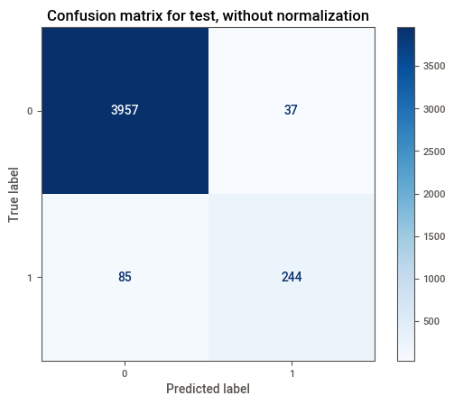

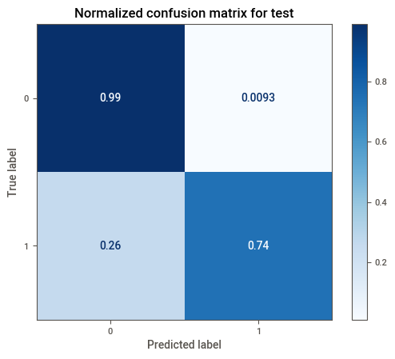

```python
# Create confusion matrices for test data.
titles_options = [("Confusion matrix for test, without normalization", None),
                  ("Normalized confusion matrix for test", 'true')]

class_names = clf_4['classifier'].classes_

for title, normalize in titles_options:
    disp = ConfusionMatrixDisplay.from_estimator(clf_4, X_test, y_test,
                                 display_labels=class_names,
                                 cmap=plt.cm.Blues,
                                 normalize=normalize)
    disp.ax_.set_title(title)

    print(title)
    print(disp.confusion_matrix)

plt.show()
```

Compared to all the previously run models, this Lasso regression model with the optimal C value achieves the highest accuracy scores for both the training and test sets so far. The training accuracy score is about 0.003 higher than the test accuracy score, suggesting that the model does not exhibit evidence of overfitting.

Additionally, looking at the confusion matrices, for houses valued at 1 million dollars or more, this Lasso regression model with optimal C also achieves the highest true positive (TP) rate and the lowest false negative rate (FN) across both the training and test sets so far, with TP = 0.75 and FN = 0.25 for the training data and TP = 0.74 and FN = 0.26 for the test data. The results indicate that the Lasso regression model with optimal C shows the best performance so far and also does not show evidence of underfitting.

However, unfortunately, the optimal value is $C=21.544$. The high value of C suggests that regularization is not very helpful for this problem.

### Task 5 - Simple decision tree

```python
from sklearn.tree import DecisionTreeClassifier
```

```python
# Append random forest classifier to preprocessing pipeline.
clf_5 = Pipeline(steps=[('preprocessor', preprocessor),
                      ('classifier', DecisionTreeClassifier(min_samples_split=2))])

clf_5.fit(X_train, y_train)

print(f"Training score: {clf_5.score(X_train, y_train):.3f}")
print(f"Test score: {clf_5.score(X_test, y_test):.3f}")
```

```
Training score: 1.000
Test score: 0.960
```

```
Confusion matrix for train, without normalization
[[16127     0]
 [    0  1163]]
Normalized confusion matrix for train
[[1. 0.]
 [0. 1.]]
```

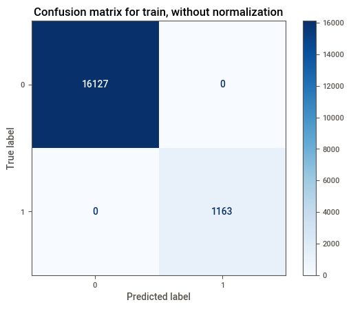

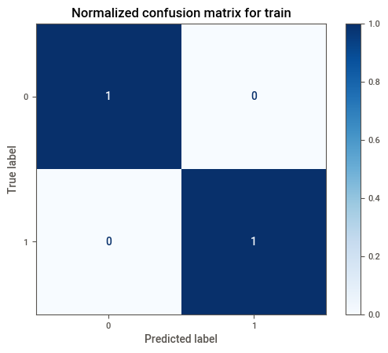

```python
# Confusion matrix for the training set
titles_options = [("Confusion matrix for train, without normalization", None),
                  ("Normalized confusion matrix for train", 'true')]

class_names = clf_5['classifier'].classes_

for title, normalize in titles_options:
    disp = ConfusionMatrixDisplay.from_estimator(clf_5, X_train, y_train,
                                 display_labels=class_names,
                                 cmap=plt.cm.Blues,
                                 normalize=normalize)
    disp.ax_.set_title(title)

    print(title)
    print(disp.confusion_matrix)

plt.show()
```

```
Confusion matrix for test, without normalization
[[3904   90]
 [  84  245]]
Normalized confusion matrix for test
[[0.9774662  0.0225338 ]
 [0.25531915 0.74468085]]
```

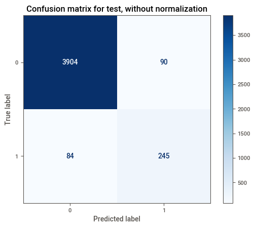

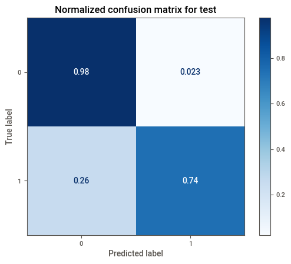

```python
# Confuion matrix for the test set
titles_options = [("Confusion matrix for test, without normalization", None),
                  ("Normalized confusion matrix for test", 'true')]

class_names = clf_5['classifier'].classes_

for title, normalize in titles_options:
    disp = ConfusionMatrixDisplay.from_estimator(clf_5, X_test, y_test,
                                 display_labels=class_names,
                                 cmap=plt.cm.Blues,
                                 normalize=normalize)
    disp.ax_.set_title(title)

    print(title)
    print(disp.confusion_matrix)

plt.show()
```

Compared to the other models I have run so far, the decision tree model performs perfectly on the training data. However, its accuracy score on the testing dataset is lower than that of most non-null logistic regression models (i.e., models 1, 2, and 4). As shown by the confusion matrices, this model achieves perfect classification on the training set, but only reaches a true positive rate of 0.74 and a false negative rate of 0.26 on the testing set. Therefore, the results indicate potential overfitting.

I do not need to create a coefficient plot because, unlike logistic regression, the decision tree does not work with coefficients. Instead, it works by recursively splitting the data until some criteria are met.

### Task 6 - a little error exploration

```python
# Load data
housingprice_df = pd.read_csv("./data/kc_house_data_regression.csv")
```

```python
housingprice_df.info()
```

```
<class 'pandas.core.frame.DataFrame'>
RangeIndex: 21613 entries, 0 to 21612
Data columns (total 18 columns):
 #   Column         Non-Null Count  Dtype
---  ------         --------------  -----
 0   bedrooms       21613 non-null  int64
 1   bathrooms      21613 non-null  float64
 2   sqft_living    21613 non-null  int64
 3   sqft_lot       21613 non-null  int64
 4   floors         21613 non-null  float64
 5   waterfront     21613 non-null  int64
 6   view           21613 non-null  int64
 7   condition      21613 non-null  int64
 8   grade          21613 non-null  int64
 9   sqft_above     21613 non-null  int64
 10  sqft_basement  21613 non-null  int64
 11  yr_built       21613 non-null  int64
 12  yr_renovated   21613 non-null  int64
 13  zipcode        21613 non-null  int64
 14  lat            21613 non-null  float64
 15  long           21613 non-null  float64
 16  sqft_living15  21613 non-null  int64
 17  price          21613 non-null  float64
dtypes: float64(5), int64(13)
memory usage: 3.0 MB
```

```python
# Fit model on training data
clf_2.fit(X_train, y_train)

# Make predictions on the test data
clf_2_predictions = clf_2.predict(X_test)

# Compare the inconsistent values between the actual test_y and the predicted values
wrong = y_test != clf_2_predictions

# Add price into the y-test
y_test_w_price = y_test.to_frame().join(housingprice_df['price'])

# Get the row index of those wrong predictions and go to extract those prices from the dataset
wrong_prices = y_test_w_price.loc[wrong, 'price']
```

```python
import matplotlib.pyplot as plt
```

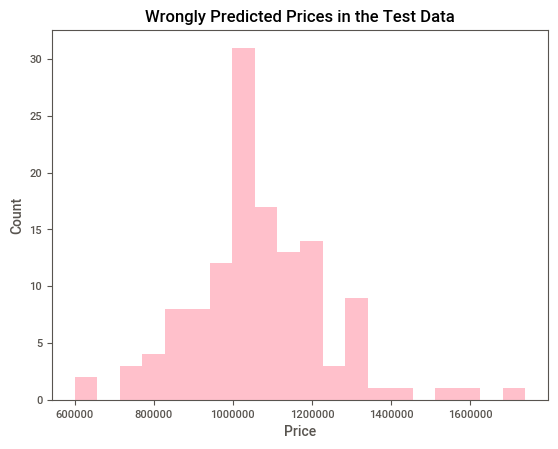

```python
# Plot the histogram
plt.hist(wrong_prices, bins=20, color = 'pink')
plt.xlabel('Price')
plt.ylabel('Count')
plt.title('Wrongly Predicted Prices in the Test Data')
plt.show()
```

Most of the properties that Model 2 fails to correctly predict are those priced around 1 million dollars, particularly those priced between 900,000 dollars and 1.2 million dollars.

## Optional Hacker Extra Credit tasks

### The Histogram based Gradient Boosting Classifier

```python
# Import the gradient boosting module
from sklearn.ensemble import HistGradientBoostingClassifier

# Need the following to encode our target variable
from sklearn.preprocessing import OrdinalEncoder
```

```python
# Create transformer objects
numeric_transformer_hgbc = StandardScaler()
categorical_transformer_hgbc = OrdinalEncoder(handle_unknown='use_encoded_value', unknown_value=np.nan)
target_transformer_hgbc = OrdinalEncoder(handle_unknown='use_encoded_value', unknown_value=np.nan)

# Combine transformers into a preprocessor step
preprocessor_hgbc = ColumnTransformer(
    transformers=[
        ('cat', categorical_transformer_hgbc, categorical_cols),
        ('num', numeric_transformer_hgbc, numeric_cols)],
        remainder='passthrough')

# Get the index number of categorical cols for later use in the call to the HistGradientBoostingclassifier()
categorical_cols_idx = [_ for _ in range(len(categorical_cols))]

# Append classifier to preprocessing pipeline.
clf_hgbc = Pipeline(steps=[('preprocessor', preprocessor_hgbc),
                      ('classifier', HistGradientBoostingClassifier(categorical_features=categorical_cols_idx))])

# Fit model
clf_hgbc.fit(X_train, y_train)

print(f"hgbc training score: {clf_hgbc.score(X_train, y_train):.3f}")
print(f"Test score: {clf_hgbc.score(X_test, y_test):.3f}")
```

```
hgbc training score: 0.997
Test score: 0.971
```

```
Confusion matrix for train, without normalization
[[16105    22]
 [   34  1129]]
Normalized confusion matrix for train
[[0.99863583 0.00136417]
 [0.02923474 0.97076526]]
```

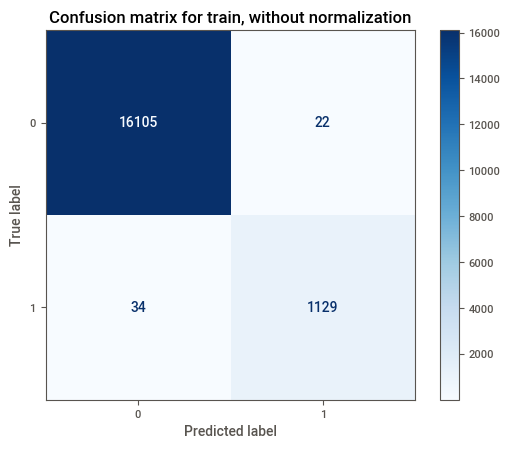

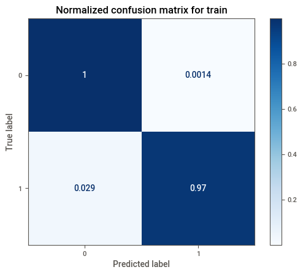

```python
# Confusion matrix for the training set
titles_options = [("Confusion matrix for train, without normalization", None),
                  ("Normalized confusion matrix for train", 'true')]

class_names = clf_hgbc['classifier'].classes_

for title, normalize in titles_options:
    disp = ConfusionMatrixDisplay.from_estimator(clf_hgbc, X_train, y_train,
                                 labels=clf_hgbc['classifier'].classes_,
                                 cmap=plt.cm.Blues,
                                 normalize=normalize)
    disp.ax_.set_title(title)

    print(title)
    print(disp.confusion_matrix)

plt.show()
```

```
Confusion matrix for test, without normalization
[[3949   45]
 [  80  249]]
Normalized confusion matrix for test
[[0.9887331  0.0112669 ]
 [0.24316109 0.75683891]]
```

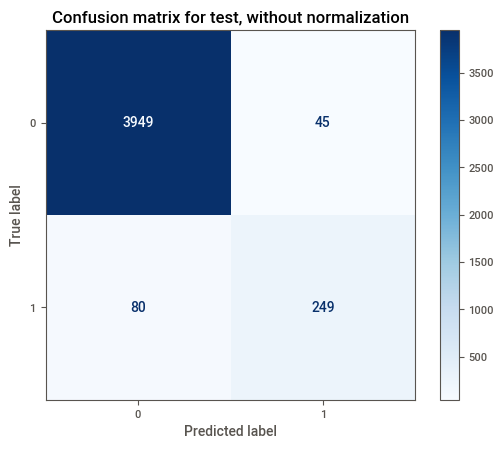

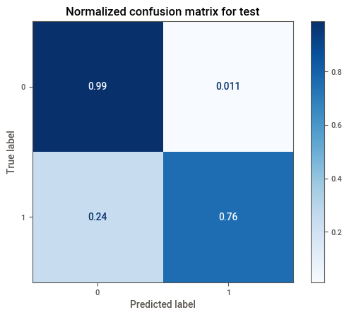

```python
# Confuion matrix for the test set
titles_options = [("Confusion matrix for test, without normalization", None),
                  ("Normalized confusion matrix for test", 'true')]

class_names = clf_hgbc['classifier'].classes_

for title, normalize in titles_options:
    disp = ConfusionMatrixDisplay.from_estimator(clf_hgbc, X_test, y_test,
                                 labels=clf_hgbc['classifier'].classes_,
                                 cmap=plt.cm.Blues,
                                 normalize=normalize)
    disp.ax_.set_title(title)

    print(title)
    print(disp.confusion_matrix)

plt.show()
```

Compared to all the logistic regression models I have run, this model with Histogram-based Gradient Boosting Classifier achieves the highest accuracy score on the training dataset, while its accuracy score on the test dataset is comparable to that of models 1, 2, and 4. However, it does have the highest true positive rate and the lowest false negative rate on the testing dataset. When compared to the simple decision tree model, its performance on the training dataset is slightly worse, while its performance on the testing dataset is slightly better.

### Sklearn's LassoCV

```python
from sklearn.linear_model import LassoCV
```

```python
housingprice_df.info()
```

```
<class 'pandas.core.frame.DataFrame'>
RangeIndex: 21613 entries, 0 to 21612
Data columns (total 18 columns):
 #   Column         Non-Null Count  Dtype
---  ------         --------------  -----
 0   bedrooms       21613 non-null  int64
 1   bathrooms      21613 non-null  float64
 2   sqft_living    21613 non-null  int64
 3   sqft_lot       21613 non-null  int64
 4   floors         21613 non-null  float64
 5   waterfront     21613 non-null  int64
 6   view           21613 non-null  int64
 7   condition      21613 non-null  int64
 8   grade          21613 non-null  int64
 9   sqft_above     21613 non-null  int64
 10  sqft_basement  21613 non-null  int64
 11  yr_built       21613 non-null  int64
 12  yr_renovated   21613 non-null  int64
 13  zipcode        21613 non-null  int64
 14  lat            21613 non-null  float64
 15  long           21613 non-null  float64
 16  sqft_living15  21613 non-null  int64
 17  price          21613 non-null  float64
dtypes: float64(5), int64(13)
memory usage: 3.0 MB
```

```python
# As the `kc_house_data_regression.csv` has a different number of variables than `kc_house_data_classification.csv`
# I just redid all the following steps for this new dataset.
# Even though I know there's only one predictor from `kc_house_data_classification.csv` that is missing in the `kc_house_data_classification.csv`.

cols_to_keep_p = housingprice_df.columns.tolist()

# Create a list of categorical variables and a list of numeric variables
categorical_cols_p = [col for col in housingprice_df.columns[:-1] if housingprice_df[col].nunique() < 6] + ['zipcode'] + ['grade']
numeric_cols_p = [col for col in housingprice_df.columns[:-1] if col not in categorical_cols_p]
```

```python
# Examine the lists
assert len(cols_to_keep_p[:-1]) == len(categorical_cols_p) + len(numeric_cols_p)
```

```python
# Data partitioning
X_p = housingprice_df.iloc[:, 0:17]
y_p = housingprice_df.iloc[:, 17]
X_train_p, X_test_p, y_train_p, y_test_p = train_test_split(X_p, y_p, test_size=0.2, random_state=73)
```

```python
# Create transformer objects
numeric_transformer_p = StandardScaler()
categorical_transformer_p = OneHotEncoder(handle_unknown='ignore')

# Combine transformers into a preprocessor step
preprocessor_p = ColumnTransformer(
    transformers=[
        ('num', numeric_transformer_p, numeric_cols_p),
        ('cat', categorical_transformer_p, categorical_cols_p)])

# LassoCV
clf_modelLCV = LassoCV(cv=5, random_state=0, max_iter=5000, alphas=200)

# Append classifier to preprocessing pipeline.
clf_LCV = Pipeline(steps=[('preprocessor', preprocessor_p),
                      ('classifier', clf_modelLCV)])

# Fit model on training data
clf_LCV.fit(X_train_p, y_train_p)

print(f"Training score: {clf_LCV.score(X_train_p, y_train_p):.3f}")
print(f"Test score: {clf_LCV.score(X_test_p, y_test_p):.3f}")
print(f"Optimal alpha:{clf_LCV.named_steps['classifier'].alpha_:.3f}")
```

```
Training score: 0.831
Test score: 0.814
Optimal alpha:249.163
```

The LassoCV selects an optimal alpha value of around 249, which suggests that the regulation really helps with the problem. Additionally, its accuracy score for the training dataset is 0.831, and the accuracy score for the test dataset is 0.814, suggesting that there is no clear evidence for either overfitting or underfitting.